# DeepMetrica Customer Segmentation Analysis

Tugrul Ozsoy

18 Eylül 2020

[figure not shown]

# 1 Introduction

The data we analyzed in order to define best options in terms of customer segments for DeepMetrica, is exported with the help of `alexa.com`. The data basically says HOW MANY WEBSITES THERE ARE IN THESE CATEGORIES. These websites are classified through main and sub-categories and is tried to find chart-toppers. Finally, the visitor numbers and traffic of websites are obtained with the help of `similarweb.com`.

# 2 Main Categories

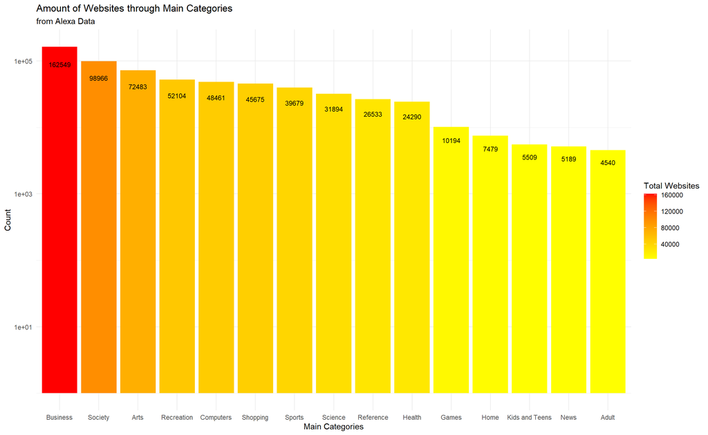

When we look main website categories, we see that Business, Society, and Arts tagged websites constituted the biggest parts in term of numbers. At first glance, it comes to mind the websites like:

`bloomberg.com`  
`businessinsider.com`  
`forbes.com`  
`nytimes.com`  
`quora.com`  
`ted.com`

`pride.com`  
`al-islam.org`  
`answersingenesis.org`  
`quinnemanuel.com`

`pinterest.com`  
`deviantart.com`  
`artsy.com`

# 3 Sub-Categories

## 3.1 Adult and Arts

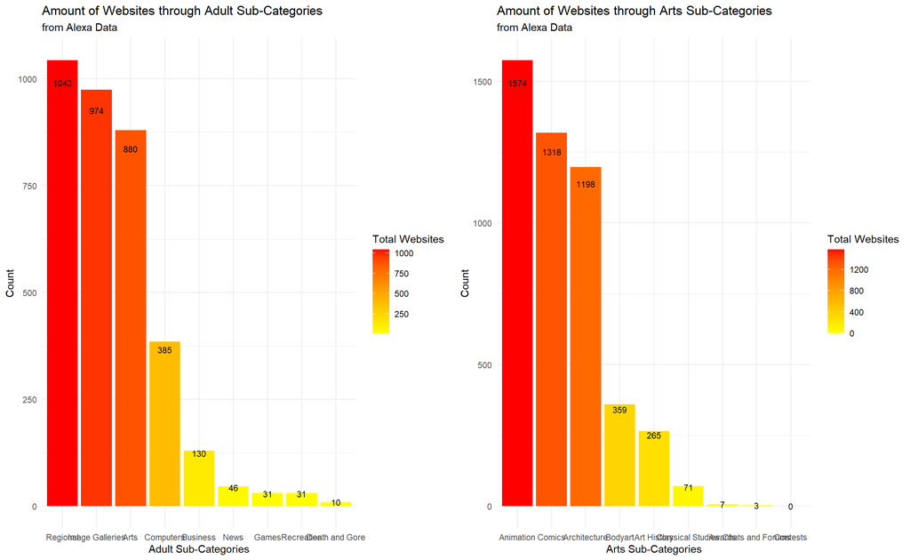

`pinterest.com`  
`deviantart.com`  
`artsy.com`

If we transform Computers keyword to Technology to reach a more general base, we obtain websites like:

`techcrunch.com`  
`wired.com`  
`digitaltrends.com`  
`engadget.com`  
`thenextweb.com`

ANIMATION, COMICS and ARCHITECTURE sub-categories takes biggest part in Arts main category. Examples to this kind of websites can be given as:

`motionographer.com`  
`creativebloq.com`  
`animaker.com`  
`animationmagazine.net`

`pixton.com`  
`dccomics.com`  
`imagecomics.com`

`hypebeast.com` - 8.90 million visitors per month  
`archdaily.com` - 7.56 million visitors per month  
`apartmenttherapy.com` - 6.67 million visitors per month

## 3.2 Business and Computers

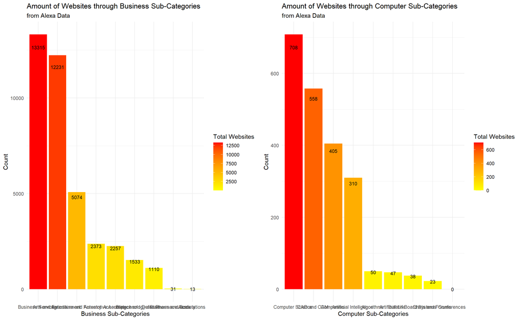

Similarly, in sub-categories of Business, BUSINESS SERVICES and ARTS&ENTERTAINMENT take the biggest part.

`myshopify.com`  
`service-now.com`  
`shopify.com`

`youtube.com`  
`netflix.com`  
`youtu.be`

In sub-categories of Computers, COMPUTER SCIENCE and CAD&CAM (Computer-Aided Design/Manufacturing) are the chart-toppers:

`zoom.us`  
`wordpress.com`  
`adobe.com`

## 3.3 Games and Health

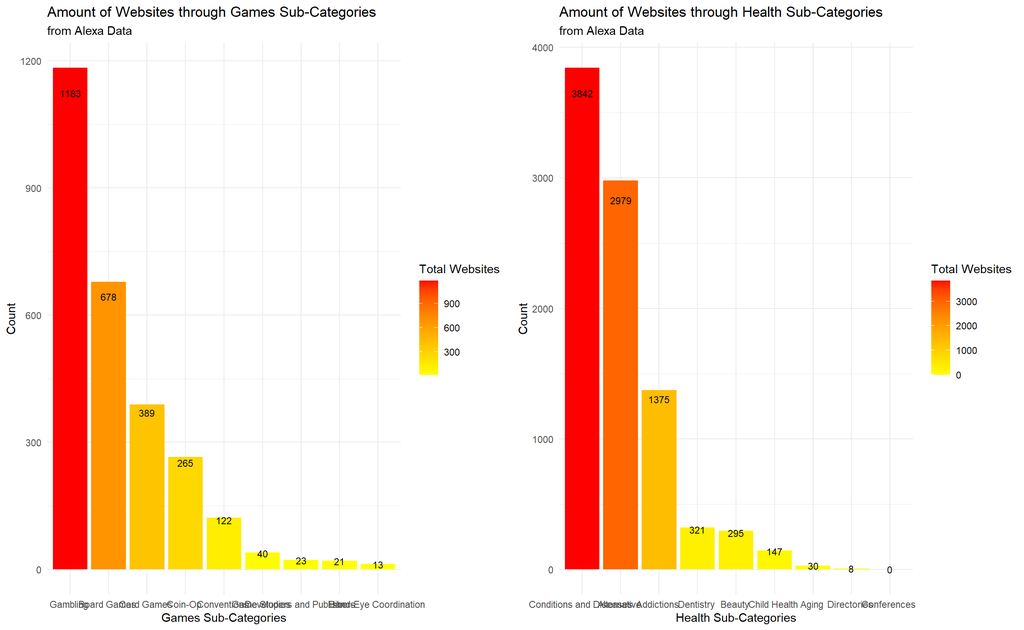

In sub-categories of Games, GAMBLING and BOARD GAMES are the chart-toppers:

`bet365.com`  
`nesine.com`  
`hollywoodbets.net`

In sub-categories of Health, CONDITIONS&DISEASES, ALTERNATIVE and ADDICTIONS are the chart-toppers:

`webmd.com`  
`verywellhealth.com`  
`cancer.com`

## 3.4 Home and Kids&Teens

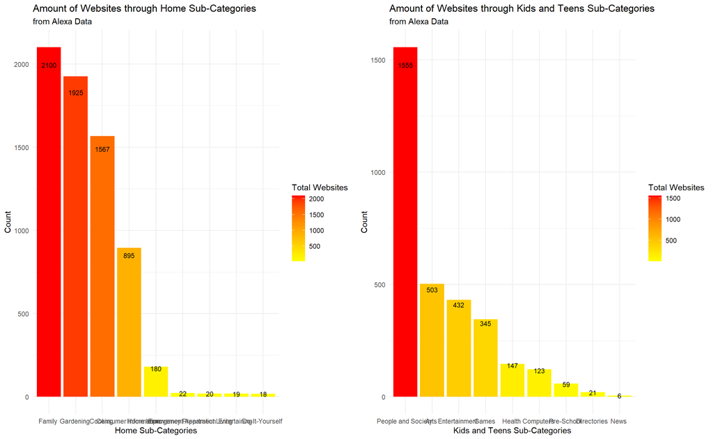

In sub-categories of Home, FAMILY, GARDENING and COOKING are the chart-toppers:

`ikea.com`  
`homedepot.com`  
`lowes.com`  
`diy.com`  
`goodhousekeeping.com`

`cookpad.com`  
`allrecipes.com`  
`chefkoch.de`

In sub-categories of Kids&Teens, PEOPLE AND SOCIETY is the only chart-topper:

`jw.com`  
`badoo.com`  
`tinder.com`

## 3.5 News and Recreation

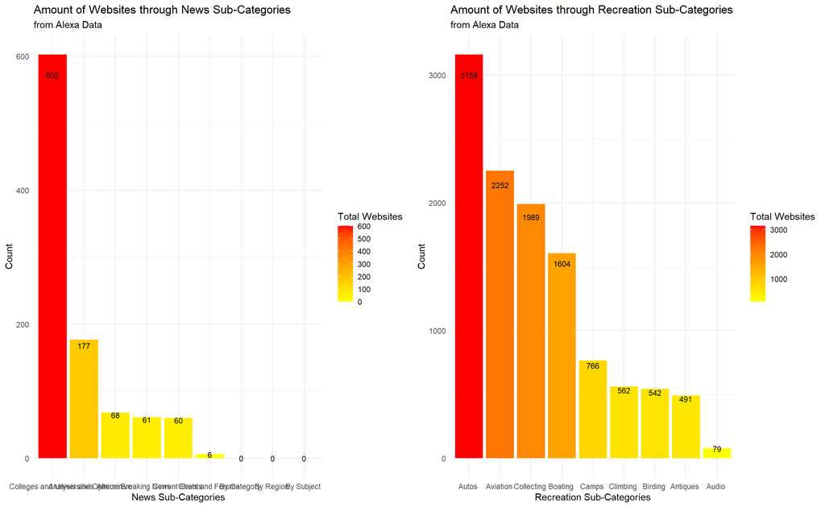

In sub-categories of News, COLLEGE AND UNIVERSITIES is the only chart-topper:

`cambridge.org`  
`mit.edu`  
`harvard.edu`  
`jhu.edu`

In sub-categories of Recreation, AUTOS, AVIATION and COLLECTING are the chart-toppers:

`carview.co.jp`  
`autozone.com`  
`carsales.com.au`  
`sahibinden.com`

`windy.com`  
`flightradar24.com`  
`airliners.com`  
`boeing.com`

`todocolleccion.net`  
`ucoin.net`  
`stardoll.com`

## 3.6 Sports and Science

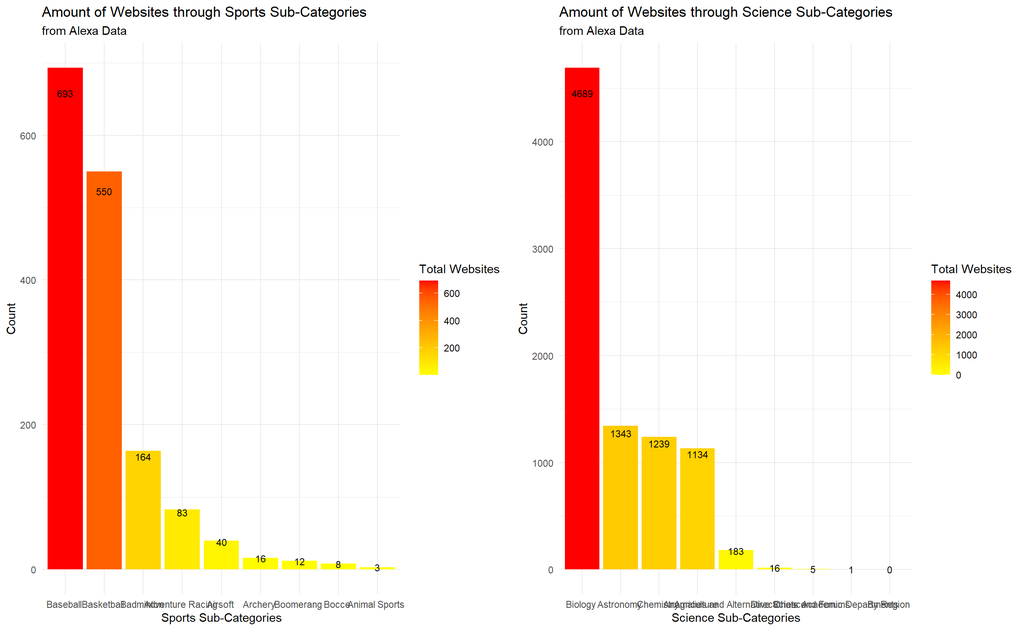

In sub-categories of Sports, BASEBALL and BASKETBALL are the chart-toppers:

`mlb.com`  
`betman.co.kr`  
`baseball-reference.com`  
`fangraphs.com`

`nba.com`  
`nba-streams.xyz`  
`basketball-reference.com`

In sub-categories of Science, BIOLOGY, ASTRONOMY, and CHEMISTRY are the chart-toppers:

`inaturalist.org`  
`doi.org`

`space.com`  
`cloudynights.com`  
`heavens-above.com`

`sigmaaldrich.com`  
`ptable.com`  
`chemicalaid.com`

## 3.7 Shopping and Society

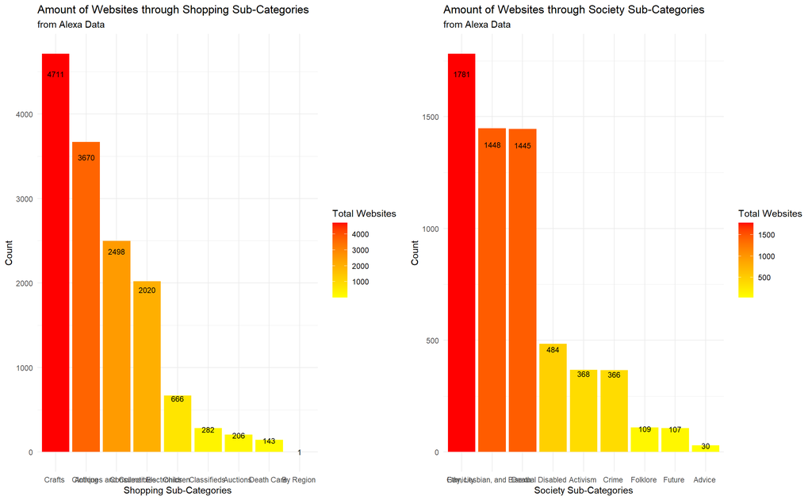

In sub-categories of Shopping, CRAFT and CLOTHING are the chart-toppers:

`ravelry.com`  
`thesprucecrafts.com`  
`lovecrafts.com`  
`hobbylobby.com`  
`li.ru`

In sub-categories of Society, ETHNCITY and GAY&LESBIAN&BISEXUAL, and DEATH are the chart-toppers:

`fabguys.com`  
`bullchat.com`  
`mensnet.jp`

`findagrave.com`  
`legacy.com`  
`dignitymemorial.com`

## 3.8 Reference

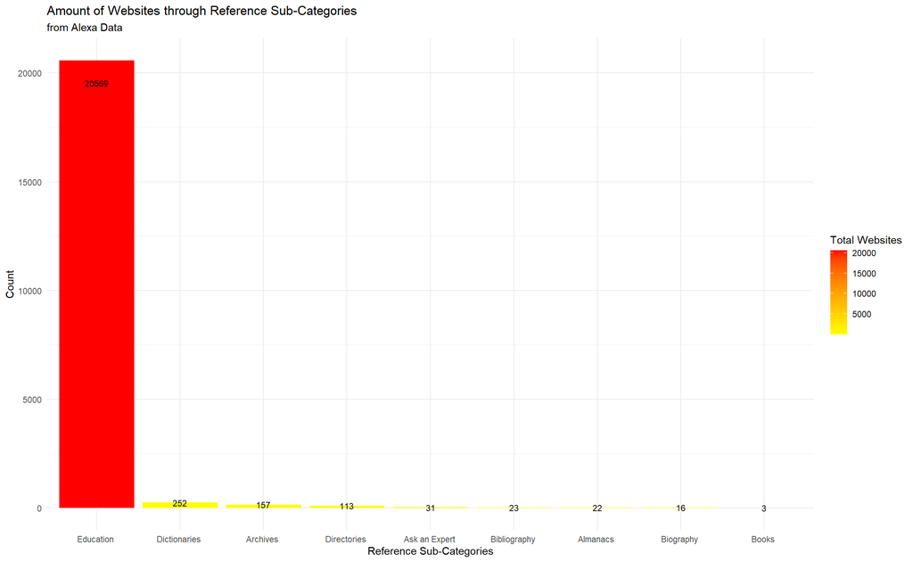

In sub-categories of Reference, EDUCATION is the only chart-topper:

`instructure.com`  
`udemy.com`  
`coursera.org`  
`khanacademy.org`  
`duolingo.com`  
`quizlet.com`

# 4 Conclusion

We have classified Main and Sub-Categories of the websites in which data exported from the Alexa. The barcharts showing categories which are powerful in term of weight are made. Example websites which have possibility to be our future customers are given based on those weights. In a statistical and overall view, it can be concluded that the most weighted categories are EDUCATION, BUSINESS SERVICES, and ARTS&ENTERTAINMENT with 20569, 13315, 12231 respectively.